# Leapfrog Episiotomy rates, 2016-2019

2020-09-25

By **Christian McDonald**, Assistant Professor of Practice  
School of Journalism and Media, Moody College of Communication  
University of Texas at Austin

This analysis looks at episiotomy rates using the [Texas Health Care Information Collection’s Texas Inpatient Public Use Data File](https://www.dshs.texas.gov/thcic/hospitals/Inpatientpudf.shtm). The definition to calculate the rates comes from the [2020 Leapfrog Hospital Survey p118](https://www.leapfroggroup.org/sites/default/files/Files/2020HospitalSurvey_20200413_8.1%20%28version%201%29.pdf). I start with data filtered from the THCIC data using the Leapfrog specs. That process is explained in “01-process-lf-epi-loop”.

## Setup and import

```r
library(tidyverse)
library(janitor)
library(DT)
library(tigris)

# suppresses grouping warning
options(dplyr.summarise.inform = FALSE)
```

```r
test_flag <- F

### test data
path_test <- "data-test/lf_del_vag_loop_test.rds"

### production data
path_prod <- "data-processed/lf_del_cleaned.rds"

### import based on flag
if (test_flag == T) del_vag_excl <- read_rds(path_test) else del_vag_excl <- read_rds(path_prod)

del_vag_excl %>% nrow()
```

```
## [1] 930101
```

### Set the episiotomy cases

This creates a column for cases where episiotomy is true. We have to look through each of the surgical procedure columns to check for the code.

> I’d like to refactor this method, but at least it is easy to see and understand.

```r
# list of codes for episiotomy, which is really one: 0W8NXZZ
epi_list <- read_rds("procedures-lists/lf_epi.rds") %>% .$epi
epi_list
```

```
## [1] "0W8NXZZ"
```

```r
lf_epi <- del_vag_excl %>%
  mutate(
    EPI = case_when(
      PRINC_SURG_PROC_CODE %in% epi_list ~ TRUE,
      OTH_SURG_PROC_CODE_1 %in% epi_list ~ TRUE,
      OTH_SURG_PROC_CODE_2 %in% epi_list ~ TRUE,
      OTH_SURG_PROC_CODE_3 %in% epi_list ~ TRUE,
      OTH_SURG_PROC_CODE_4 %in% epi_list ~ TRUE,
      OTH_SURG_PROC_CODE_5 %in% epi_list ~ TRUE,
      OTH_SURG_PROC_CODE_6 %in% epi_list ~ TRUE,
      OTH_SURG_PROC_CODE_7 %in% epi_list ~ TRUE,
      OTH_SURG_PROC_CODE_8 %in% epi_list ~ TRUE,
      OTH_SURG_PROC_CODE_9 %in% epi_list ~ TRUE,
      OTH_SURG_PROC_CODE_10 %in% epi_list ~ TRUE,
      OTH_SURG_PROC_CODE_11 %in% epi_list ~ TRUE,
      OTH_SURG_PROC_CODE_12 %in% epi_list ~ TRUE,
      OTH_SURG_PROC_CODE_13 %in% epi_list ~ TRUE,
      OTH_SURG_PROC_CODE_14 %in% epi_list ~ TRUE,
      OTH_SURG_PROC_CODE_15 %in% epi_list ~ TRUE,
      OTH_SURG_PROC_CODE_16 %in% epi_list ~ TRUE,
      OTH_SURG_PROC_CODE_17 %in% epi_list ~ TRUE,
      OTH_SURG_PROC_CODE_18 %in% epi_list ~ TRUE,
      OTH_SURG_PROC_CODE_19 %in% epi_list ~ TRUE,
      OTH_SURG_PROC_CODE_20 %in% epi_list ~ TRUE,
      OTH_SURG_PROC_CODE_21 %in% epi_list ~ TRUE,
      OTH_SURG_PROC_CODE_22 %in% epi_list ~ TRUE,
      OTH_SURG_PROC_CODE_23 %in% epi_list ~ TRUE,
      OTH_SURG_PROC_CODE_24 %in% epi_list ~ TRUE,
      TRUE ~ FALSE
    )
  )
```

This completes the processing of the data.

## Searchable table: Episiotomy rates by hospital, combined years

Hospitals with fewer than 120 deliveries excluded.

```r
lf_epi_rate_hosp <- lf_epi %>%
  group_by(THCIC_ID, PROVIDER_NAME, EPI) %>%
  summarise(
    EPI_CNT = n()
  ) %>%
  pivot_wider(names_from = EPI, values_from = EPI_CNT) %>%
  rename(
    EPIF = "FALSE",
    EPIT = "TRUE"
  ) %>%
  mutate(
    TOTAL = EPIF + EPIT,
    EPIRATE = round_half_up((EPIT / TOTAL) * 100,1)
  ) %>%
  select(THCIC_ID, PROVIDER_NAME, TOTAL, EPIF, EPIT, EPIRATE) %>%
  filter(
    TOTAL >= 120
    ) %>%
  arrange(EPIRATE %>% desc())

lf_epi_rate_hosp %>%
    datatable()
```

|  | THCIC_ID | PROVIDER_NAME | TOTAL | EPIF | EPIT | EPIRATE |
| --- | --- | --- | --- | --- | --- | --- |
| 1 | 919000 | Baylor Scott &amp; White Medical Center Sunnyvale | 379 | 250 | 129 | 34 |
| 2 | 280000 | Hopkins County Memorial Hospital | 216 | 158 | 58 | 26.9 |
| 3 | 006000 | Matagorda Regional Medical Center | 1399 | 1034 | 365 | 26.1 |
| 4 | 315003 | Dallas Regional Medical Center | 1684 | 1247 | 437 | 26 |
| 5 | 370000 | Mission Regional Medical Center | 3759 | 2786 | 973 | 25.9 |
| 6 | 462000 | Val Verde Regional Medical Center | 2000 | 1516 | 484 | 24.2 |
| 7 | 301000 | Doctors Hospital-Laredo | 3541 | 2707 | 834 | 23.6 |
| 8 | 109000 | Covenant Medical Center-Lakeside | 1470 | 1127 | 343 | 23.3 |
| 9 | 019000 | Valley Regional Medical Center | 3880 | 3015 | 865 | 22.3 |
| 10 | 975159 | Christus Mother Frances Hospital Sulphur Springs | 1292 | 1009 | 283 | 21.9 |

[output cut: 235 more lines]

## Episiotomy rates by hospital, by year

A look at the episiotomy rates for hospitals by year. We create the rate using the EPI column we created above, then pivot to do the math. We pivot again to see the years nicely in a table. Excludes hospitals with fewer than 30 deliveries in a given year.

```r
# pivot to crate the rate based on logical EPI column
lf_epi_rate_hosp_yr <- lf_epi %>%
  group_by(YR, THCIC_ID, PROVIDER_NAME, EPI) %>%
  summarise(
    EPI_CNT = n()
  ) %>%
  pivot_wider(names_from = EPI, values_from = EPI_CNT) %>%
  rename(
    EPIF = "FALSE",
    EPIT = "TRUE"
  ) %>%
  mutate(
    TOTAL = EPIF + EPIT,
    EPIRATE = round_half_up((EPIT / TOTAL) * 100,1)
  )

# select, pivot to see years.
lf_epi_rate_hosp_yr_table <- lf_epi_rate_hosp_yr %>%
  filter(TOTAL >= 30) %>%
  select(YR, THCIC_ID, PROVIDER_NAME, EPIRATE) %>%
  pivot_wider(names_from = YR, values_from = EPIRATE) %>%
  arrange(`2019` %>% desc())

lf_epi_rate_hosp_yr_table %>% datatable()
```

|  | THCIC_ID | PROVIDER_NAME | 2016 | 2017 | 2018 | 2019 |
| --- | --- | --- | --- | --- | --- | --- |
| 1 | 301000 | Doctors Hospital-Laredo | 18.6 | 18.9 | 26.2 | 31.3 |
| 2 | 462000 | Val Verde Regional Medical Center | 24.4 | 25.2 | 21.8 | 25.4 |
| 3 | 315003 | Dallas Regional Medical Center | 34.8 | 28.7 | 20.2 | 23.4 |
| 4 | 654000 | Golden Plains Community Hospital | 11.8 | 8.9 | 12.2 | 23.1 |
| 5 | 436000 | CHI St Lukes Health Brazosport | 11 | 13.8 | 17.5 | 21.5 |
| 6 | 026000 | Childress Regional Medical Center | 10.2 | 20.6 | 25.2 | 21.3 |
| 7 | 297000 | Wilson N Jones Regional Medical Center | 16.9 | 21.2 | 23 | 21.2 |
| 8 | 006000 | Matagorda Regional Medical Center | 22.3 | 31.1 | 30.3 | 21.1 |
| 9 | 046000 | Faith Community Hospital |  |  |  | 20.8 |
| 10 | 130000 | The Hospitals of Providence Memorial Campus | 23.6 | 22 | 20.7 | 20.1 |

[output cut: 242 more lines]

## Laredo hospitals

Filtering above sets for Laredo hospitals.

### Episiotomy rate combined years, Laredo hospitals

From combined years of the data.

```r
lf_epi_rate_hosp %>%
  filter(str_detect(PROVIDER_NAME, "Laredo"))
```

| THCIC_ID | PROVIDER_NAME | TOTAL | EPIF | EPIT | EPIRATE |
| --- | --- | --- | --- | --- | --- |
| 301000 | Doctors Hospital-Laredo | 3541 | 2707 | 834 | 23.6 |
| 207001 | Laredo Medical Center | 7169 | 5887 | 1282 | 17.9 |

### Episiotomy rates by year, Laredo hospitals

The table above, filtered for Laredo.

```r
# filter for Laredo
lf_epi_rate_hosp_yr_table %>%
  filter(str_detect(PROVIDER_NAME, "Laredo"))
```

| THCIC_ID | PROVIDER_NAME | 2016 | 2017 | 2018 | 2019 |
| --- | --- | --- | --- | --- | --- |
| 301000 | Doctors Hospital-Laredo | 18.6 | 18.9 | 26.2 | 31.3 |
| 207001 | Laredo Medical Center | 16.7 | 17.7 | 18.3 | 18.9 |

### Chart: Episiotomy rates by year, Laredo

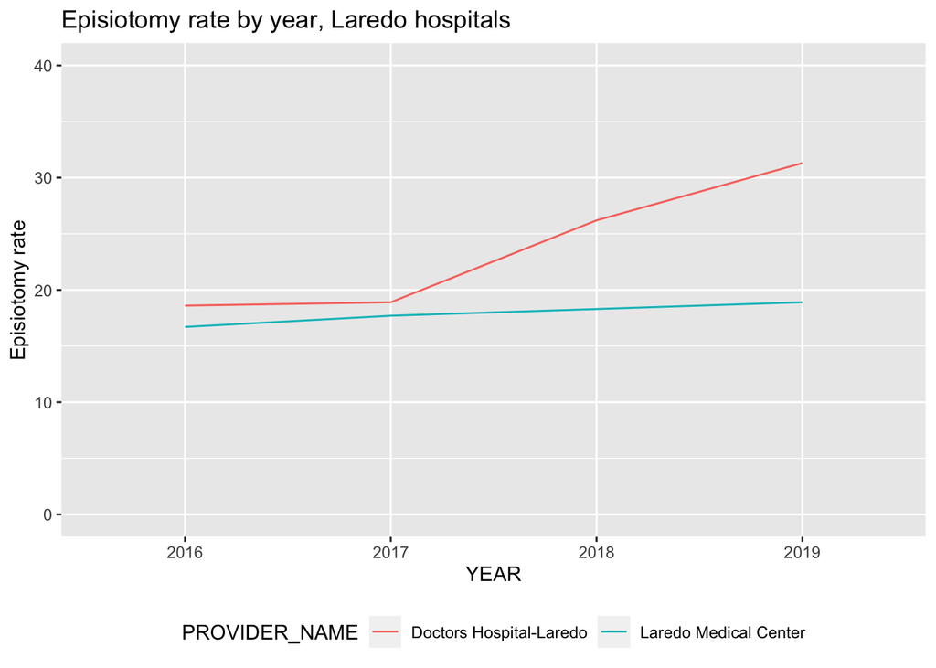

```r
lf_epi_rate_hosp_yr %>%
  filter(str_detect(PROVIDER_NAME, "Laredo")) %>%
  ggplot(aes(YR, EPIRATE)) +
  geom_line(aes(group = PROVIDER_NAME, color = PROVIDER_NAME)) +
  expand_limits(y = c(0,40)) +
  theme(legend.position="bottom", legend.box = "vertical") +
  labs(title = "Episiotomy rate by year, Laredo hospitals", x = "YEAR", y = "Episiotomy rate")
```

### Chart: Episiotomy rates by quarter, Laredo

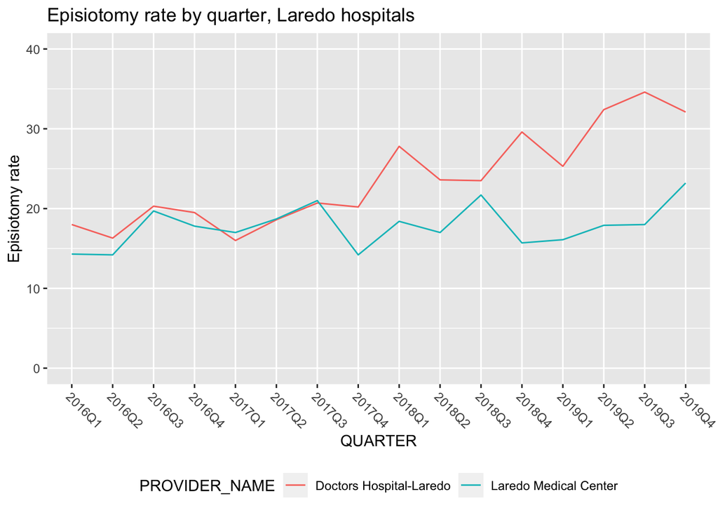

```r
lf_epi_rate_hosp_qr_laredo_plot <- lf_epi %>%
  filter(str_detect(PROVIDER_NAME, "Laredo")) %>%
  group_by(DISCHARGE, PROVIDER_NAME, EPI) %>%
  summarise(
    EPI_CNT = n()
  ) %>%
  pivot_wider(names_from = EPI, values_from = EPI_CNT) %>%
  rename(
    EPIF = "FALSE",
    EPIT = "TRUE"
  ) %>%
  mutate(
    TOTAL = EPIF + EPIT,
    EPIRATE = round_half_up((EPIT / TOTAL) * 100,1)
  )

lf_epi_rate_hosp_qr_laredo_plot %>%
  ggplot(aes(DISCHARGE, EPIRATE)) +
  geom_line(aes(group = PROVIDER_NAME, color = PROVIDER_NAME)) +
  expand_limits(y = c(0,40)) +
  theme(legend.position="bottom", legend.box = "vertical",axis.text.x=element_text(angle = -45, hjust = 0)) +
  labs(title = "Episiotomy rate by quarter, Laredo hospitals", x = "QUARTER", y = "Episiotomy rate")
```

## Patient county

Get FIPS codes lookup for county names.

```r
tx_fips <- fips_codes %>%
  filter(state == "TX") %>%
  select(county_code, county)
# peek
tx_fips %>% head(2)
```

|  | county_code | county |
| --- | --- | --- |
| 1 | 001 | Anderson County |
| 2 | 003 | Andrews County |

### Episiotomies by county, full data

This looks at rates by the patient’s county (the hospital could be elsewhere.). Currently not filtered for any minimum caseload since it is a 3+ year period.

```r
lf_epi_rate_county <- lf_epi %>%
  group_by(PAT_COUNTY, EPI) %>%
  summarise(
    EPI_CNT = n()
  ) %>%
  # join for county names
  left_join(tx_fips, by=c( "PAT_COUNTY" = "county_code")) %>%
  ungroup() %>%
  rename(COUNTY = county) %>%
  # pivot for mutates
  pivot_wider(names_from = EPI, values_from = EPI_CNT) %>%
  rename(
    EPIF = "FALSE",
    EPIT = "TRUE"
  ) %>%
  mutate(
    TOTAL = EPIF + EPIT,
    EPIRATE = round_half_up((EPIT / TOTAL) * 100,1)
  ) %>%
  select(PAT_COUNTY, COUNTY, TOTAL, EPIF, EPIT, EPIRATE) %>%
  # filter by total
  # filter(
  #   TOTAL >= 300
  #   ) %>%
  arrange(EPIRATE %>% desc())

lf_epi_rate_county %>%
    datatable()
```

|  | PAT_COUNTY | COUNTY | TOTAL | EPIF | EPIT | EPIRATE |
| --- | --- | --- | --- | --- | --- | --- |
| 1 | 045 | Briscoe County | 27 | 21 | 6 | 22.2 |
| 2 | 465 | Val Verde County | 1954 | 1523 | 431 | 22.1 |
| 3 | 321 | Matagorda County | 1397 | 1096 | 301 | 21.5 |
| 4 | 223 | Hopkins County | 1025 | 819 | 206 | 20.1 |
| 5 | 033 | Borden County | 5 | 4 | 1 | 20 |
| 6 | 479 | Webb County | 9837 | 7889 | 1948 | 19.8 |
| 7 | 427 | Starr County | 2447 | 1974 | 473 | 19.3 |
| 8 | 379 | Rains County | 203 | 166 | 37 | 18.2 |
| 9 | 119 | Delta County | 150 | 123 | 27 | 18 |
| 10 | 475 | Ward County | 447 | 367 | 80 | 17.9 |

[output cut: 245 more lines]

### Episiotimies by county, by year

Group by patient county. This table excludes fewer than 30 cases in a county in a given year.

```r
# pivot to crate the rate based on logical EPI column
lf_epi_rate_county_yr <- lf_epi %>%
  group_by(YR, PAT_COUNTY, EPI) %>%
  summarise(
    EPI_CNT = n()
  ) %>%
  # Join to add county names
  left_join(tx_fips, by=c( "PAT_COUNTY" = "county_code")) %>%
  ungroup() %>%
  rename(COUNTY = county) %>%
  pivot_wider(names_from = EPI, values_from = EPI_CNT) %>%
  rename(
    EPIF = "FALSE",
    EPIT = "TRUE"
  ) %>%
  mutate(
    TOTAL = EPIF + EPIT,
    EPIRATE = round_half_up((EPIT / TOTAL) * 100,1)) %>%
    # filter caseload
    filter(TOTAL >= 30)

# select, pivot to see years.
lf_epi_rate_county_yr_table <- lf_epi_rate_county_yr %>%
  select(YR, COUNTY, EPIRATE) %>%
  pivot_wider(names_from = YR, values_from = EPIRATE) %>%
  arrange(`2019` %>% desc())

lf_epi_rate_county_yr_table %>% datatable()
```

|  | COUNTY | 2016 | 2017 | 2018 | 2019 |
| --- | --- | --- | --- | --- | --- |
| 1 | Childress County | 7.7 | 15.4 | 13.9 | 26 |
| 2 | Webb County | 17.3 | 18.3 | 21.1 | 23 |
| 3 | Val Verde County | 23.9 | 21.8 | 20.2 | 22 |
| 4 | Lynn County | 13.7 | 10.2 | 9.1 | 19.2 |
| 5 | Hutchinson County | 12.2 | 9.7 | 14.2 | 17.1 |
| 6 | Goliad County | 8.9 | 15.6 | 9.7 | 16.7 |
| 7 | Parmer County | 14.9 | 20 | 9.4 | 16.7 |
| 8 | Matagorda County | 20 | 26.2 | 23.8 | 16.6 |
| 9 | Brooks County | 8.2 | 5.8 | 8.2 | 16.4 |
| 10 | Ward County | 23.8 | 20 | 12.8 | 16.4 |

[output cut: 202 more lines]

## Summaries

### Statewide episiotomy rate

We combine all years of data to compare the percentage of episiotomy cases. The **TRUE** value is the percentage of cases where an episiotomy is performed.

```r
lf_epi %>%
  tabyl(EPI) %>%
  rename(count = n) %>%
  adorn_pct_formatting()
```

| EPI | count | percent |
| --- | --- | --- |
| FALSE | 856384 | 92.1% |
| TRUE | 73717 | 7.9% |

Creating a summary table in case we want it.

```r
lf_epi_rate_tx_summary <- lf_epi %>%
  group_by(EPI) %>%
  summarize(CNT = n()) %>%
  pivot_wider(names_from = EPI, values_from = CNT) %>%
  rename(
    EPIF = "FALSE",
    EPIT = "TRUE"
  ) %>%
  mutate(
    SUMMARY = "TX",
    CATEGORY = "EPISIOTOMY",
    MEASUREMENT = "RATE",
    TOTAL = EPIF + EPIT,
    VALUE = round_half_up((EPIT / TOTAL) * 100,1) # EPIRATE
  ) %>%
  select(SUMMARY, CATEGORY, MEASUREMENT, VALUE)

lf_epi_rate_tx_summary
```

| SUMMARY | CATEGORY | MEASUREMENT | VALUE |
| --- | --- | --- | --- |
| TX | EPISIOTOMY | RATE | 7.9 |

### Episiotomy rate statewide by year

```r
lf_epi_rate_tx_yr_summary <- lf_epi %>%
  group_by(YR, EPI) %>%
  summarise(
    EPI_CNT = n()
  ) %>%
  pivot_wider(names_from = EPI, values_from = EPI_CNT) %>%
  rename(
    EPIF = "FALSE",
    EPIT = "TRUE"
  ) %>%
  mutate(
    SUMMARY = "TX",
    CATEGORY = "EPISIOTOMY",
    MEASUREMENT = "RATE",
    TOTAL = EPIF + EPIT,
    VALUE = round_half_up((EPIT / TOTAL) * 100,1) # EPIRATE
  ) %>%
  select(
    YR, SUMMARY, CATEGORY, MEASUREMENT, VALUE
  )

lf_epi_rate_tx_yr_summary
```

| YR | SUMMARY | CATEGORY | MEASUREMENT | VALUE |
| --- | --- | --- | --- | --- |
| 2016 | TX | EPISIOTOMY | RATE | 9.6 |
| 2017 | TX | EPISIOTOMY | RATE | 8.1 |
| 2018 | TX | EPISIOTOMY | RATE | 7.3 |
| 2019 | TX | EPISIOTOMY | RATE | 6.5 |

### Episiotomy rate by hospital: Averaged, by year

```r
lf_epi_rate_hosp_yr_summary <- lf_epi_rate_hosp_yr %>%
  ungroup() %>%
  group_by(YR) %>%
  summarize(
    SUMMARY = "HOSPITAL",
    CATEGORY = "EPISIOTOMY",
    MEASUREMENT = "MEAN_OF_RATE",
    # MEDIAN = median(EPIRATE),
    VALUE = round_half_up(mean(EPIRATE, na.rm = TRUE),1) #MEAN
  )

lf_epi_rate_hosp_yr_summary
```

| YR | SUMMARY | CATEGORY | MEASUREMENT | VALUE |
| --- | --- | --- | --- | --- |
| 2016 | HOSPITAL | EPISIOTOMY | MEAN_OF_RATE | 9.9 |
| 2017 | HOSPITAL | EPISIOTOMY | MEAN_OF_RATE | 8.9 |
| 2018 | HOSPITAL | EPISIOTOMY | MEAN_OF_RATE | 8.2 |
| 2019 | HOSPITAL | EPISIOTOMY | MEAN_OF_RATE | 7.3 |

## Write files

Writing out aggregate files. Here is a list of CSVs exports:

- lf_epi_rate_county_yr: Grouped by YR, PAT_COUNTY, COUNTY. Aggregations are EPIF (Count Epi False), EPIT (Count Epi True), TOTAL (Count of all vaginal deliveries), EPIRATE.

Plus some data outputs for 03-analysis-summaries.

```r
# lf_epi %>% write_rds("data-processed/epi.rds")

if (test_flag == F) lf_epi_rate_tx_yr_summary %>%
  write_rds("data-processed/lf_epi_rate_tx_yr_summary.rds")

if (test_flag == F) lf_epi_rate_hosp_yr_summary %>%
  write_rds("data-processed/lf_epi_rate_hosp_yr_summary.rds")

if (test_flag == F) lf_epi_rate_hosp_yr %>%
  write_rds("data-processed/lf_epi_rate_hosp_yr.rds")

if (test_flag == F) lf_epi_rate_county_yr %>%
  write_csv("exports/lf_epi_rate_county_yr.csv")

beepr::beep(4)
```